# hw_06

```r
##data
x = c(110.5, 105.4, 118.1, 104.5, 93.6, 84.1, 77.8, 75.6)
y = c(5.755, 5.939, 6.010, 6.545, 6.730, 6.750, 6.899, 7.862)
```

### a. Give the least squares estimate (β1^) of the slope _{1}β1 Give a brief interpretation of β1^

```r
get_coeff <- lm(y~x)
get_coeff
```

```
##
## Call:
## lm(formula = y ~ x)
##
## Coefficients:
## (Intercept)            x
##    10.13746     -0.03717
```

Answer: ^B1 = -0.03717; ^B1 is the slope of the best fit line, determining the EXPECTED change in y as x changes

```r
summary(get_coeff)
```

```
##
## Call:
## lm(formula = y ~ x)
##
## Residuals:
##      Min       1Q   Median       3Q      Max
## -0.34626 -0.27605 -0.09448  0.27023  0.53495
##
## Coefficients:
##              Estimate Std. Error t value Pr(>|t|)
## (Intercept) 10.137455   0.842265  12.036    2e-05 ***
## x           -0.037175   0.008653  -4.296  0.00512 **
## ---
## Signif. codes:  0 '***' 0.001 '**' 0.01 '*' 0.05 '.' 0.1 ' ' 1
##
## Residual standard error: 0.3624 on 6 degrees of freedom
## Multiple R-squared:  0.7547, Adjusted R-squared:  0.7138
## F-statistic: 18.46 on 1 and 6 DF,  p-value: 0.005116
```

```r
summary(get_coeff)$coefficients[,3-4]
```

```
##              Std. Error   t value     Pr(>|t|)
## (Intercept) 0.842264864 12.035947 1.995872e-05
## x           0.008653462 -4.295933 5.115513e-03
```

```r
anova(get_coeff)
```

|  | Df | Sum Sq | Mean Sq | F value | Pr(>F) |
| --- | --- | --- | --- | --- | --- |
| x | 1 | 2.4235668 | 2.4235668 | 18.45504 | 0.005115513 |
| Residuals | 6 | 0.7879367 | 0.1313228 | NA | NA |

Answer: Both t and F-statistic are significant (i.e., p-values < 0.05), indicating that this regression model is a good fit for the data at hand

### c. Construct a 95% confidence interval for the intercept *{0}β0 by hand using the equation from the lecture, compare your results with those from R and briefly interpret the 95% confidence interval. You can get t*{n-2,/2}tn−2,α/2 using R code qt(alpha/2, n-2) where alpha is 0.05 here.

```r
qt(0.05/2, 6,lower.tail = FALSE)
```

```
## [1] 2.446912
```

```r
summary(get_coeff)$coefficients
```

```
##                Estimate  Std. Error   t value     Pr(>|t|)
## (Intercept) 10.13745532 0.842264864 12.035947 1.995872e-05
## x           -0.03717469 0.008653462 -4.295933 5.115513e-03
```

```r
confint(get_coeff, level = 0.95)
```

```
##                   2.5 %      97.5 %
## (Intercept)  8.07650745 12.19840320
## x           -0.05834895 -0.01600043
```

### d. Give the fitted regression line (as a equation that looks like =a+bxy^=a+bx) and the raw residuals.

```r
coef(get_coeff)[1]
```

```
## (Intercept)
##    10.13746
```

```r
coef(get_coeff)["x"]
```

```
##           x
## -0.03717469
```

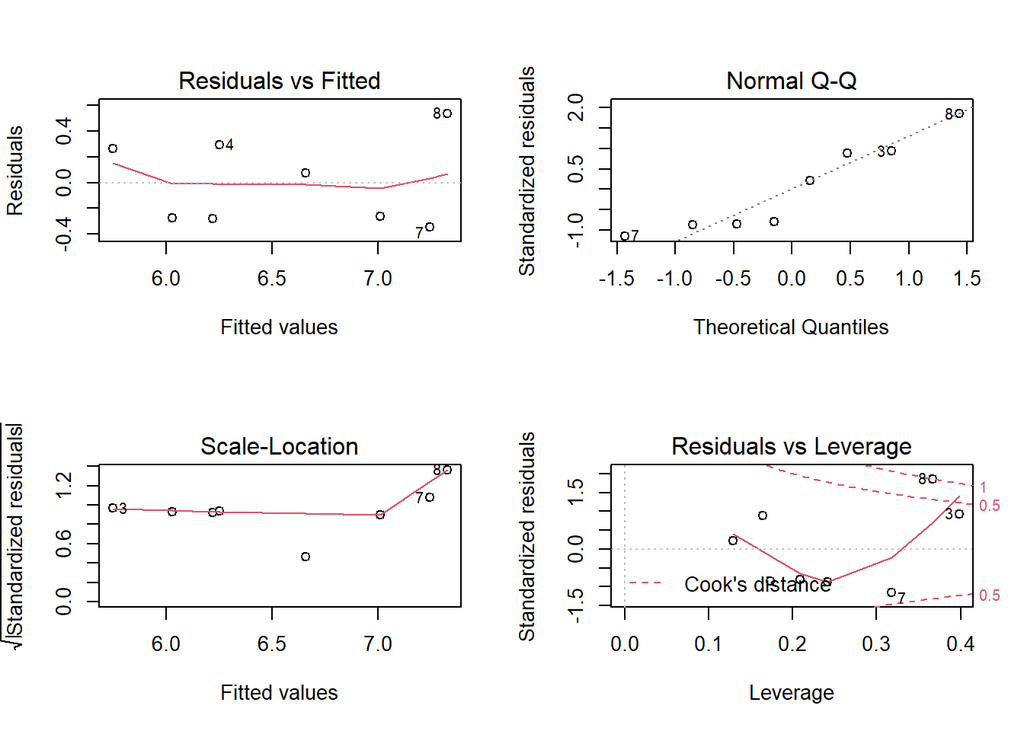

```r
par(mfrow = c(2, 2))
plot(get_coeff)
```

Line: Y = 10.13746 -0.03717469x

### e. Give an estimate (<sup>{2}σ</sup>2) of the error variance (^{2}σ2).

```r
summary(get_coeff)
```

```
##
## Call:
## lm(formula = y ~ x)
##
## Residuals:
##      Min       1Q   Median       3Q      Max
## -0.34626 -0.27605 -0.09448  0.27023  0.53495
##
## Coefficients:
##              Estimate Std. Error t value Pr(>|t|)
## (Intercept) 10.137455   0.842265  12.036    2e-05 ***
## x           -0.037175   0.008653  -4.296  0.00512 **
## ---
## Signif. codes:  0 '***' 0.001 '**' 0.01 '*' 0.05 '.' 0.1 ' ' 1
##
## Residual standard error: 0.3624 on 6 degrees of freedom
## Multiple R-squared:  0.7547, Adjusted R-squared:  0.7138
## F-statistic: 18.46 on 1 and 6 DF,  p-value: 0.005116
```

Answer: estimated standard error for residuals obtained from summary table above = 0.3624, with 6 degrees of freedom

### f. Estimate the expected yield of a rice variety (*{0}μ0) that has height x*{0}=100x0=100 and provide a 95% confidence interval.

```r
predict(get_coeff, newdata = data.frame(x = 100), interval = "confidence")
```

```
##        fit      lwr      upr
## 1 6.419986 6.096321 6.743651
```

### g. Predict the yield of a new rice variety that has height x_{0}=100x 0=100 and provide a 95% prediction interval. Compare the results with those from (f), which one is wider?

```r
predict(get_coeff, newdata = data.frame(x = 100), interval = "prediction")
```

```
##        fit      lwr      upr
## 1 6.419986 5.476038 7.363934
```

Answer: 6.419986, with a lower and upper prediction interval of 5.476038 and 7.363934, respectively

The prediction intervals are wider, because, in addition to accounting for the standard error of the mean value (the only error accounted for by estimating confidence intervals), the prediction intervals must also account for the error of the predicted value (i.e., prediction intervals must account for more error than confidence intervals, causing them to have a wider range)

### h. Compute the coefficient of determination R^{2}R2 and briefly interpret what does it mean.

```r
summary(get_coeff)$r.squared
```

```
## [1] 0.7546518
```

Answer: About 75% of the variance in y (rice yield) is accounted for by the variance in x (rice height).

##2.This problem is designed to demonstrate why residuals are plotted against y^(instead of yy). Consider the following (artificial) data set that was constructed so that the relationship between yy and xx is quadratic. It is immediately evident that a linear fit is not appropriate. However, we adopt the point of view that the residual plot will provide diagnostic information on the lack of fit.

```r
d <- data.frame(x = c(1, 2, 3, 4, 5, 6, 7, 8, 9),
y = c(-2.08, -0.72, 0.28, 0.92, 1.20, 1.12, 0.68, -0.12, -1.28))
```

### a. Plot yy vs. xx.

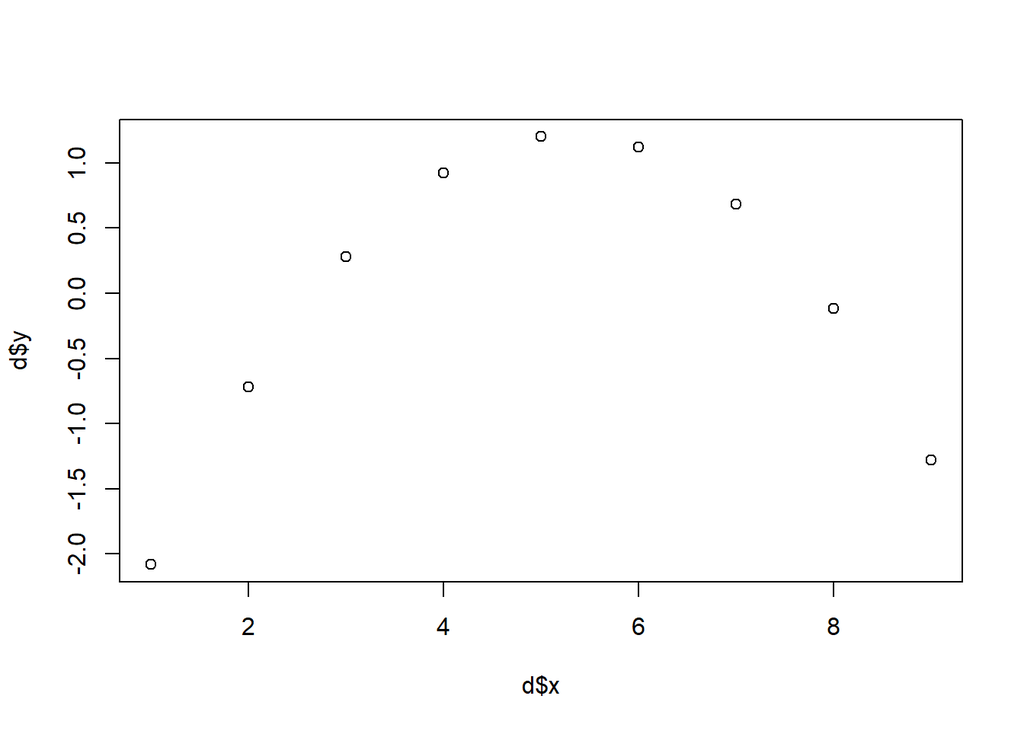

```r
plot(d$x, d$y)
```

### b. Plot the raw residuals vs. yy.

```r
d_lm_model = lm(y ~ x, data=d)
d_lm_model
```

```
##
## Call:
## lm(formula = y ~ x, data = d)
##
## Coefficients:
## (Intercept)            x
##        -0.5          0.1
```

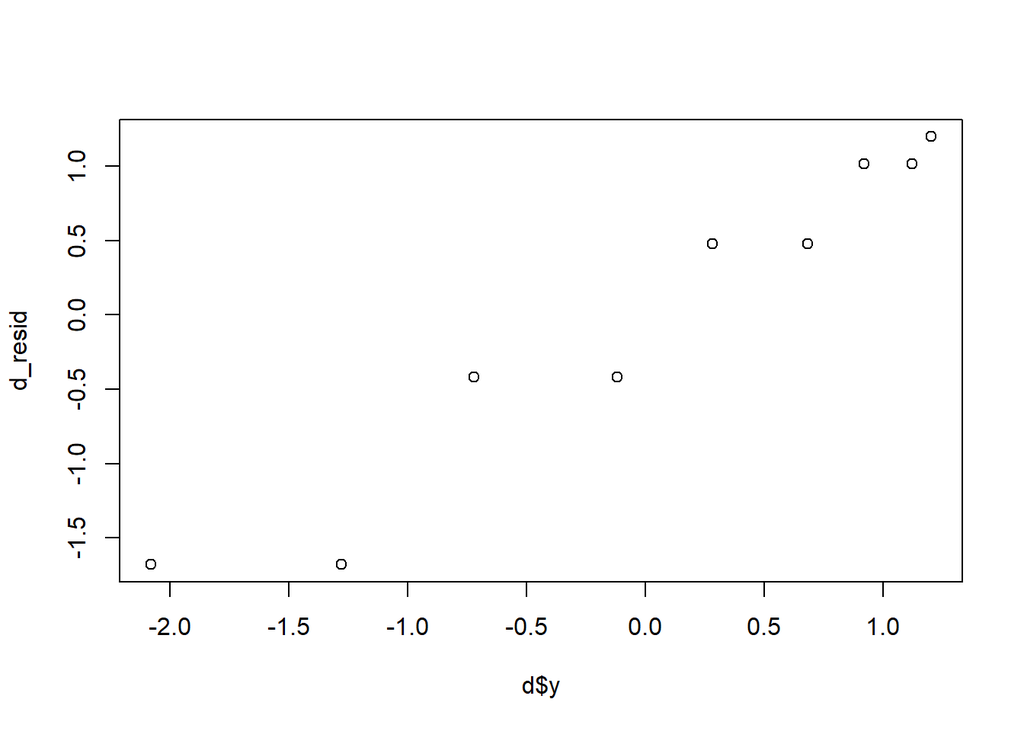

```r
d_resid = resid(d_lm_model)
plot(d$y, d_resid)
```

### c. Plot the raw residuals vs. xx.

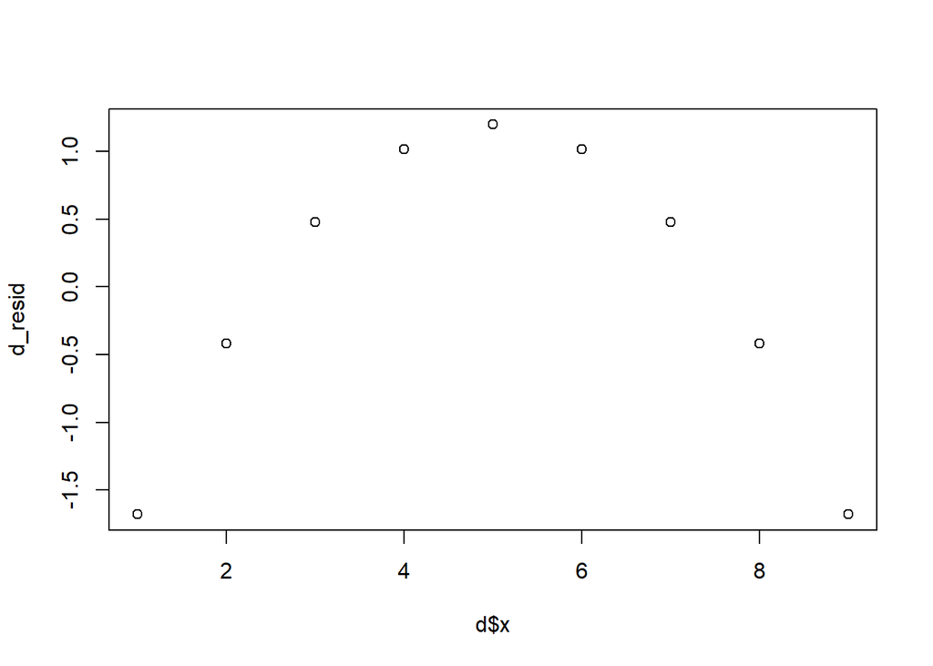

```r
plot(d$x, d_resid)
```

### d. lot the raw residuals vs. y^.

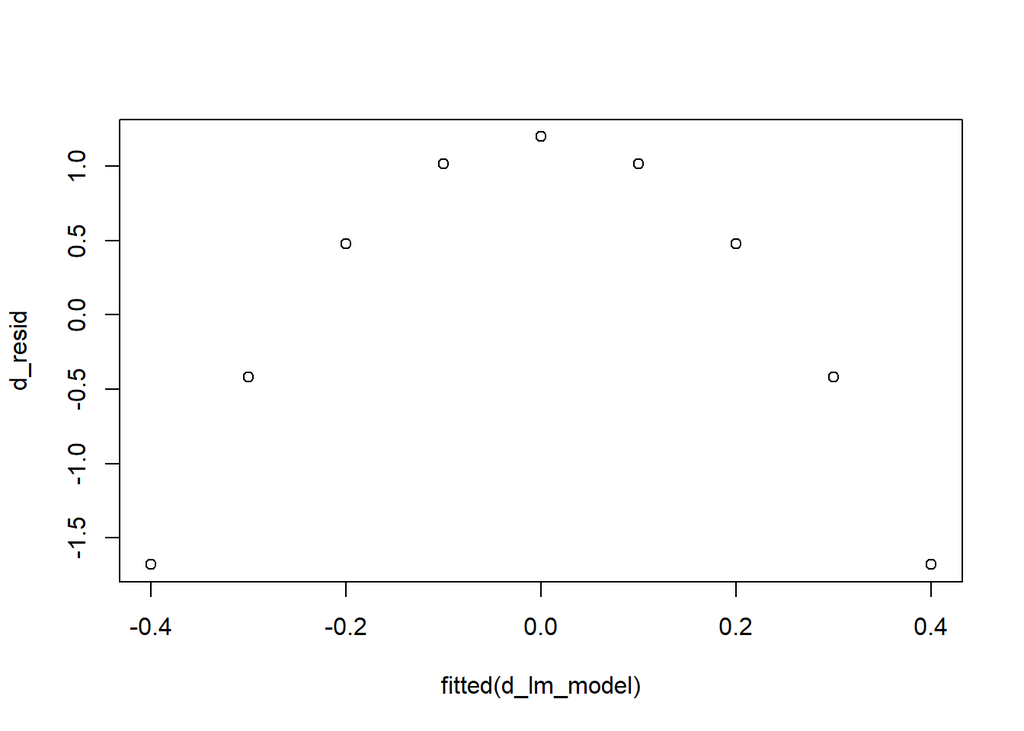

```r
plot(fitted(d_lm_model ), d_resid)
```

### e. Compare the plots from (b), (c), and (d). Is there a meaningful difference between (c) and (d)? Explain. Which of the plots (b) or (d) gives a better indication of the lack of fit? Explain.

Answer: Plots (a), (c), and (d) all show the non-linearity of the data, while (b) indicates the possibility of a linear relationship. (c) and (d) differ only in the scale on the x-axis; however, they both still indicate that a linear model will not fit the data at hand, so this difference is not very meaningful. Plot (d) gives a better indication of the lack of fit, due to the plotted data clearly being non-linear (the data in plot b, however, looks linear, therefore it does not provide insight into the lack of fit)